# CensusMapper Demo

Jens von Bergmann

2017-07-31

We demonstrate how to import data from the [CensusMapper](https://CensusMapper.ca) API. The code for this notbook can be found on [GitHub](https://github.com/mountainMath/cancensus).

To work with the CensusMapper API we need to specify our API key. We load the API key in the environment variable “CM_API_KEY”, which we assume was set prior to running the script. We could also specify it directly in the code, but than we have to be careful not to expose our API key when sharing our code.

```r
library(cancensus)
# set environment variable via
# Sys.setenv(CM_API_KEY='<your API key>')
# or
# options(cancensus.api_key)='<your API key>'
```

```r
#set the data vectors we are interested in
vectors=c("v_CA16_408","v_CA16_409","v_CA16_410","v_CA16_412","v_CA16_413","v_CA16_414","v_CA16_415","v_CA16_416","v_CA16_417")
#set the regions we are intereseted in
regions=list(CMA="59933")
#load the data
census_data <- get_census(dataset='CA16',level='CT',regions=regions,vectors=vectors)
```

[output not shown]

[output cut: 17 more lines]

[output not shown]

## Mapping

We compute a the percentage of single detached dwellings out of all occupied dwelling units and map it.

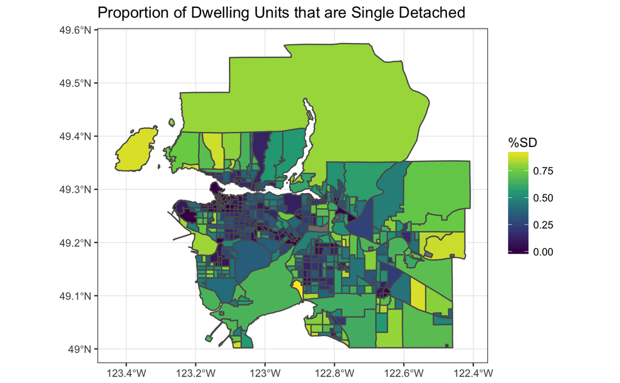

```r
# compute percentage of single detached
census_data$sd <- census_data$`v_CA16_409: Single-detached house` / census_data$`v_CA16_408: Occupied private dwellings by structural type of dwelling data`
library(sf)
# Use the latest version of ggplot2 to effortlessly plot sf
# objects and for the viridis colour scales:
# devtools::install_github("tidyverse/ggplot2")
library(ggplot2)
ggplot(census_data) +
  geom_sf(aes(fill = sd)) +
  scale_fill_viridis_c("%SD") +
  ggtitle("Proportion of Dwelling Units that are Single Detached") +
  theme_bw()
```

## Other visualizations

Or we can explore the data through non-map based means, for example how the proportion of single detached and duplex dwelling relate. Duplex dwellings are in most cases suited single family homes. We can explore how the relationship between single family homes and duplexes depend on the municipal regulations allowing for secondary suites.

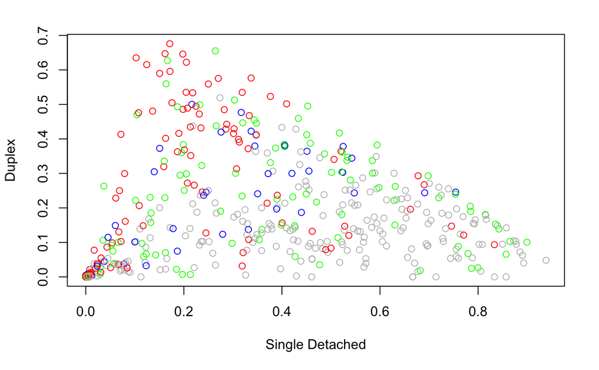

```r
census_data$duplex <- census_data$`v_CA16_414: Apartment or flat in a duplex`/ census_data$`v_CA16_408: Occupied private dwellings by structural type of dwelling data`
census_data$color_code <- ifelse(census_data$`Region Name` == "Vancouver", 'red', ifelse(census_data$`Region Name` == "Burnaby", 'blue', ifelse(census_data$`Region Name` == "Surrey", 'green', 'grey')))
plot(census_data$sd, census_data$duplex, xlab="Single Detached", ylab="Duplex", col=census_data$color_code)
```